# Assignment04 VIS

Jessica Tang

10/7/2020

```r
library(osmdata)
library(opentripplanner)
library(tidyverse)
library(sf)
library(ggthemes)
library(ggspatial)
```

```r
boston_hosp <- st_read("http://bostonopendata-boston.opendata.arcgis.com/datasets/8f1e5741a4ee4c0f82925d17aab3c002_2.kml?outSR=%7B%22latestWkid%22%3A2249%2C%22wkid%22%3A102686%7D")
```

I filtered some values out so that my map wouldn’t be at such a large scale. I know this is not the best way to do this (still not quite understanding how to use coord_sf(xlim, ylim)).

```r
boston_hosp <- boston_hosp %>%
  filter(!Name == "VA Bos. Healthcare System - W. Roxbury",
         !Name == "Carney Hospital",
         !Name == "Kindred Hospital",
         !Name == "St. Elizabeth's Hospital",
         !Name == "MGH at the Navy Yard") %>%
  mutate(fromPlace = geometry)
```

```r
opq(bbox = "Boston MA USA") %>%
  add_osm_feature(key = "highway") %>%
  osmdata_xml(file = "OTP/graphs/default/boston_streets.osm")
```

```r
MA_state_plane <- "+proj=lcc +lat_1=41.71666666666667 +lat_2=42.68333333333333 +lat_0=41 +lon_0=-71.5 +x_0=200000 +y_0=750000 +ellps=GRS80 +units=m +no_defs"

boston_street_features <- opq(bbox = "Boston MA USA") %>%
  add_osm_feature(key = "highway") %>%
  osmdata_sf()

boston_streets <- boston_street_features$osm_lines %>%
  st_transform(crs = MA_state_plane)
```

```r
path_otp <- otp_dl_jar("OTP")
```

```r
path_data <- file.path(getwd(), "OTP")
path_otp <- paste(path_data, "otp.jar", sep = "/")

otp_build_graph(otp = path_otp, dir = path_data, memory = 1024)
```

```r
otp_setup(otp = path_otp, dir = path_data, memory = 1024)
```

```r
otpcon <- otp_connect()
```

```r
iso_5min_walk <-
  otp_isochrone(otpcon = otpcon, fromPlace = boston_hosp,
                mode = "walk", cutoffSec = 300) %>%
  st_transform(crs = MA_state_plane) %>%
  mutate(mode = "walk")

iso_5min_drive <-
  otp_isochrone(otpcon = otpcon, fromPlace = boston_hosp,
                mode = "car", cutoffSec = 300) %>%
  st_transform(crs = MA_state_plane) %>%
  mutate(mode = "drive")

iso_5min_bike <-
  otp_isochrone(otpcon = otpcon, fromPlace = boston_hosp,
                mode = "bicycle", cutoffSec = 300) %>%
  st_transform(crs = MA_state_plane) %>%
  mutate(mode = "bike")

iso_all_modes <- rbind(iso_5min_drive, iso_5min_walk, iso_5min_bike)
```

## Figure 1: Overall Map

From a glance, hospitals in downtown Boston are more bike-accessible than hospitals in neighborhoods of southern Boston. For those hospitals, driving is the most accessible mode.

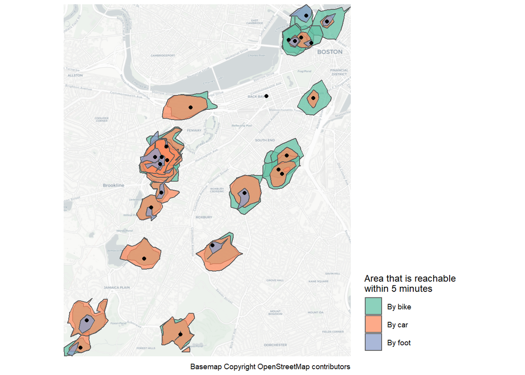

```r
right_side <- st_bbox(iso_all_modes)$xmax
left_side  <- st_bbox(iso_all_modes)$xmin
top_side <- st_bbox(iso_all_modes)$ymax
bottom_side <- st_bbox(iso_all_modes)$ymin

ggplot(iso_all_modes) +
  annotation_map_tile(zoomin = 0, type = "cartolight", progress = "none") +
  geom_sf(aes(fill = mode),
          alpha = 0.75) +
  geom_sf(data = boston_hosp) +
  coord_sf(
           xlim = c(left_side, right_side),
           ylim = c(bottom_side, top_side), expand = FALSE) +
  scale_fill_brewer(name = "Area that is reachable \nwithin 5 minutes",
                    labels = c("By bike","By car","By foot"),
                    palette = "Set2") +
  labs(caption = "Basemap Copyright OpenStreetMap contributors") +
  theme_map() +
  theme(legend.position = "right")
```

## Figure 2: Comparing Biking and Driving

```r
iso_areas <- iso_all_modes %>%
  mutate(area = st_area(iso_all_modes)) %>%
  st_set_geometry(NULL) %>%
  pivot_wider(names_from = mode, values_from = area)


iso_areas <- iso_areas %>%
  mutate(walk = as.numeric(walk),
         bike = as.numeric(bike),
         drive = as.numeric(drive))
```

I added a line with a slope of 1 (i.e., bike area = drive area) to see how many points fall above and below it. I’m not sure why my x-scale is starting at 0.1 versus at 0.

Looks like there are 4 hospitals where you can either bike or drive and the difference is close to negligible. It’s also kind of interesting to see that there’s almost an equal number of points above and points below the line, as if to say about half of the hospitals have a greater bike-accessibility area and the other half have a greater drive-accessibility area.

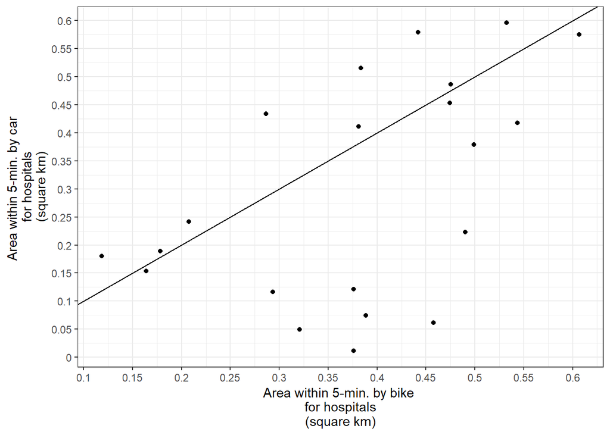

```r
ggplot(iso_areas,
       aes(x = bike, y = drive)) +
  geom_point() +
  scale_x_continuous(name =
            "Area within 5-min. by bike \nfor hospitals\n(square km)",
            breaks = breaks <- seq(0, 700000, by = 50000),
            labels = breaks / 1000000)+
  scale_y_continuous(name =
            "Area within 5-min. by car \nfor hospitals\n(square km)",
            breaks = breaks <- seq(0, 700000, by = 50000),
            labels = breaks / 1000000) +
  geom_abline(intercept = 0, slope = 1) +
  theme_bw()
```

## Figure 3: Bike and Drive Map

I created an intersection of the areas that are bike-accessible and drive-accessible within 5 minutes. I guess traffic is what makes the intersection of the areas shrink in downtown Boston.

```r
iso_intersection <- st_intersection(iso_5min_drive, iso_5min_bike)
```

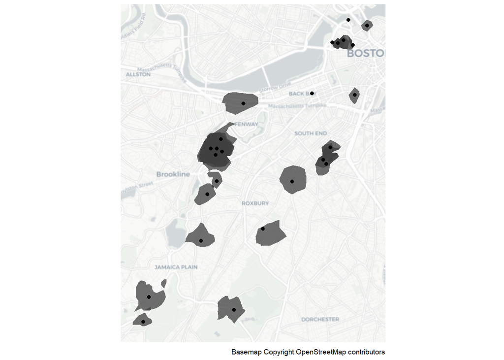

```r
ggplot(iso_intersection) +
  annotation_map_tile(zoomin = 0, type = "cartolight", progress = "none") +
  geom_sf(fill = "gray25",
          color = NA,
          alpha = 0.75) +
  geom_sf(data = boston_hosp) +
  coord_sf(xlim = c(left_side, right_side),
           ylim = c(bottom_side, top_side), expand = FALSE) +
  geom_sf(data = boston_hosp)+
  labs(caption = "Basemap Copyright OpenStreetMap contributors") +
  theme_map() +
  theme(legend.position = "right")
```

## Other Figure

A 10-minute walk is still not that long, so I decided to see the overlap between that type of isochrone and the 5-minute bike isochrones. I thought it was interesting, probably obvious, that you can get farther on a 10-minute walk than you can on a 5-minute bike ride. Assuming that either mode is being prioritized over driving, I wonder if transit planners ever have to prioritize pedestrian accessibility over bike accessibility or vice versa.

```r
iso_10min_walk <-
  otp_isochrone(otpcon = otpcon, fromPlace = boston_hosp,
                mode = "walk", cutoffSec = 600) %>%
  st_transform(crs = MA_state_plane) %>%
  mutate(mode = "1walk")
```

```r
iso_10min_walk_5min_bike <-
  rbind(iso_5min_bike,iso_10min_walk)
```

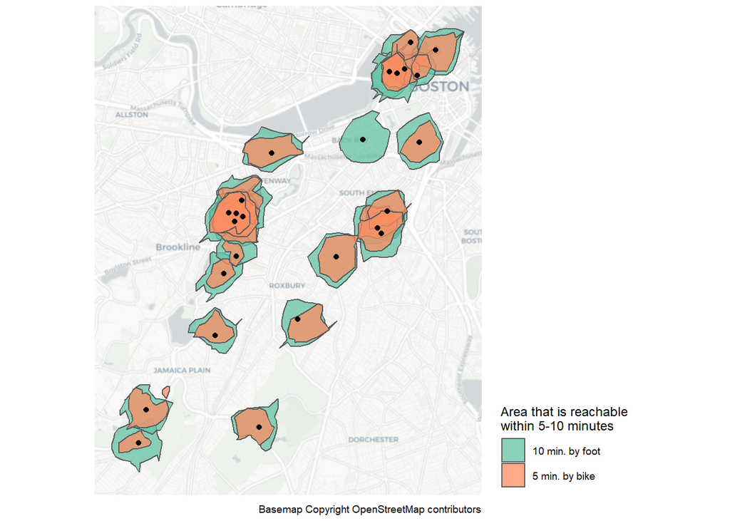

```r
ggplot(iso_10min_walk_5min_bike) +
  annotation_map_tile(zoomin = 0, type = "cartolight", progress = "none") +
  geom_sf(aes(fill = mode),
          alpha = 0.75) +
  geom_sf(data = boston_hosp) +
  coord_sf(xlim = c(left_side, right_side),
           ylim = c(bottom_side, top_side), expand = FALSE) +
  scale_fill_brewer(name = "Area that is reachable \nwithin 5-10 minutes",
                    labels = c("10 min. by foot","5 min. by bike"),
                    palette = "Set2") +
  geom_sf(data = boston_hosp)+
  labs(caption = "Basemap Copyright OpenStreetMap contributors") +
  theme_map() +
  theme(legend.position = "right")
```